# 條件機率與獨立事件

## 三門問題([Monty Hall problem](https://en.wikipedia.org/wiki/Monty_Hall_problem))

- 遊戲中有三張門，其中隨機有一張門後有一隻羊。
- 請問參賽者挑出有羊的那扇門的機率是多少？

## 三門問題([Monty Hall problem](https://en.wikipedia.org/wiki/Monty_Hall_problem))

- 遊戲中有三張門，其中隨機有一張門後有一隻羊。
- 主持人隨機挑一扇沒有羊的門打開，然後請參賽者挑一扇門。
- 請問參賽者挑出有羊的那扇門的機率是多少？

## 三門問題([Monty Hall problem](https://en.wikipedia.org/wiki/Monty_Hall_problem))

- 遊戲中有三張門，其中隨機有一張門後有一隻羊。
- 參賽者先隨機挑一扇門。
- 主持人會在參賽者選好門之後，隨機挑一扇沒有羊的門打開。然後請參賽者再重複挑一次門。
- 請問參賽者挑出有羊的那扇門的機率是多少?

## 條件機率

- 如果\(A \subseteq S\)、\(B \subseteq S\)且\(P(B) > 0\)，則\(A\)在\(B\)發生之下的機率定義為：

\[P(A|B) = \frac{P(A \cap B)}{P(B)}\]

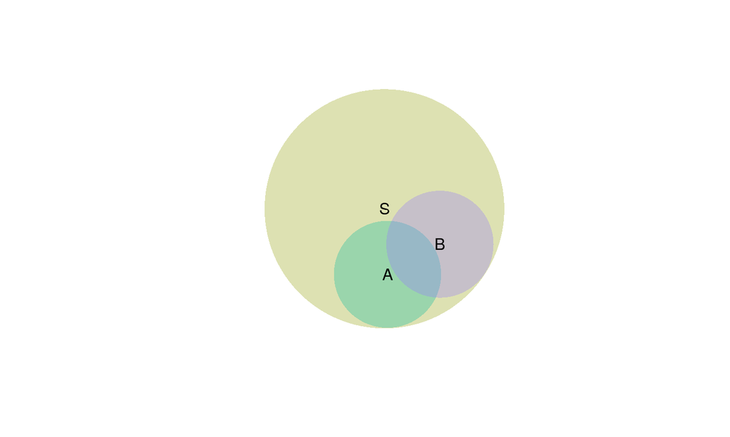

## 範例

### \(A = B\)

\[P(B|B) = 1\]

### \(P(A \cap B) = 0\)

\[P(A|B) = 0\]

## Bayes’ Rule

- \(A_1, A_2, ..., A_j\) 是 \(S\) 的 partition

\[P(A_i | B) = \frac{P(B | A_i) P(A_i)}{\sum_{j} P(B | A_j) P(A_j)}\]

- \(P(B | A_i) P(A_i) = P(B \cap A_i)\)
- \(\sum_{j} P(B | A_j) P(A_j) = \sum_j P(B \cap A_j) = P(B)\)
  - 上一個單元中 \(P(B) = P(A \cap B) + P(A^c \cap B)\) 的推廣

## 三門問題之一

- 遊戲中有三張門，其中隨機有一張門後有一隻羊。
- 請問參賽者挑出有羊的那扇門的機率是多少？

### 重新清楚的描述問題

\[\begin{array}{rcl} S & = & \{(\text{guess},\text{answer})\} \\ & = & \{(1,1),(1,2),(1,3),(2,1),(2,2),(2,3),(3,1),(3,2),(3,3)\} \\ P(i,j) & = & \frac{1}{9} \end{array}\]

### 猜中的機率

\[P(\{(1,1),(2,2),(3,3)\}) = \frac{3}{9}\]

## 三門問題之二

- 遊戲中有三張門，其中隨機有一張門後有一隻羊。
- 主持人隨機挑一扇沒有羊的門打開，然後請參賽者挑一扇門。
- 請問參賽者挑出有羊的那扇門的機率是多少？

### 重新清楚的描述問題

\[\begin{array}{rcl} S & = & \{(\text{guess},\text{answer},\text{opened})\} \\ & = & \{(i,j,k) | 1 \leq i,j,k \leq 3, i != k, j != k\} \end{array}\]

\[\{(2,2,1),(3,2,1),(2,3,1),(3,3,1),(1,1,2),(3,1,2)\}\] \[\{(1,3,2),(3,3,2),(1,1,3),(2,1,3),(1,2,3),(2,2,3)\}\]

## 三門問題之二

- 遊戲中有三張門，其中隨機有一張門後有一隻羊。
- 主持人隨機挑一扇沒有羊的門打開，然後請參賽者挑一扇門。
- 請問參賽者挑出有羊的那扇門的機率是多少？

### 猜中的機率

- 不用條件機率:

\[P(\{(2,2,1),(3,3,1),(1,1,2),(3,3,2),(1,1,3),(2,2,3)\}) = \frac{6}{12}\]

## 三門問題之二

- 遊戲中有三張門，其中隨機有一張門後有一隻羊。
- 主持人隨機挑一扇沒有羊的門打開，然後請參賽者挑一扇門。
- 請問參賽者挑出有羊的那扇門的機率是多少？

### 猜中的機率

- Let \(A\) 代表猜中的事件, \(B_k\) 代表主人打開\(k\)-th門的事件
- \(P(A) = \sum_{k = 1}^3 P(A \cap B_k) = \sum_{k = 1}^3 P(A | B_k) * P(B_k)\)
- \(P(B_k) = \frac{1}{3}\)
- \(P(B_3) = P(\{(1,1,3),(1,2,3),(2,1,3),(2,2,3)\}\)
- \(P(A \cap B_3) = P(\{(1,1,3),(2,2,3)\})\)
- \(P(A | B_3) = \frac{P(A \cap B_3)}{P(B_3)} = \frac{2}{4}\)

## 三門問題之三

- 遊戲中有三張門，其中隨機有一張門後有一隻羊。
- 參賽者先隨機挑一扇門。
- 主持人會在參賽者選好門之後，隨機挑一扇沒有羊的門打開。然後請參賽者再重複挑一次門。
- 請問參賽者挑出有羊的那扇門的機率是多少?

### 假設\(C_k\)代表參賽者挑第\(k\)扇門，假設\(C_1\)發生…

- \(C_1 = \{(1,1,3),(1,1,2),(1,2,3),(1,3,2)\}\)
- \(P(C_1) = \frac{4}{12}\)
- \(P(A | C_1) = \frac{P(A \cap C_3)}{P(C_3)} = \frac{2}{4}\)
- \(P(A) = \sum_{k} P(A | C_k) P(C_k) = \frac{1}{2}\)

## 三門問題之三

- 遊戲中有三張門，其中隨機有一張門後有一隻羊。
- 參賽者先隨機挑一扇門。
- **主持人會在參賽者選好門之後，隨機挑一扇沒有羊的門打開**。然後請參賽者再重複挑一次門。
- 請問參賽者挑出有羊的那扇門的機率是多少?

### 所以參賽者猜的位置與羊的位置應該是均勻的，但是開門的機率不一定…

- 用\((i,j)\)代表參賽者猜第\(i\)個門、羊在第\(j\)個門後
- \(P((1,1)) = P((1,2)) = ... = P((3,3)) = \frac{1}{9}\)
- \(C_1 = \{(1,1,3),(1,1,2),(1,2,3),(1,3,2)\}\)之中的事件並不是均勻的:
  - \(P((1,2,3) | (1,2)) = 1 \Rightarrow P((1,2,3)) = P((1,2)) = \frac{1}{9}\)
  - \(P((1,1,3) | (1,1)) = \frac{1}{2} \Rightarrow P((1,1,3)) = \frac{P((1,1))}{2} = \frac{1}{18}\)

## 三門問題之三

- 遊戲中有三張門，其中隨機有一張門後有一隻羊。
- 參賽者先隨機挑一扇門。
- **主持人會在參賽者選好門之後，隨機挑一扇沒有羊的門打開**。然後請參賽者再重複挑一次門。
- 請問參賽者挑出有羊的那扇門的機率是多少?

### 所以若參賽者在主持人開門之後，更換自己所選擇的門…

- 只要\(i \neq j\)則代表參賽者最後會猜中
- \(P(i \neq j | C_1) = \frac{P(\{(1,2,3),(1,3,2)\})}{P(C_1)} = \frac{P((1,2,3)) + P((1,3,2))}{P(C_1)} = \frac{2/9}{1/3} = \frac{2}{3}\)

## 獨立事件

### 範例

- 丟兩次獨立的骰子，第一次的事件是\(S_1\)、第二次是\(S_2\)
  - \(S_1 = S_2 = \{1,2,3,4,5,6\}\)
  - 對所有的\(k \in \{1,2,3,4,5,6\}\)：\(P_{S_1}(k) = P_{S_2}(k) = \frac{1}{6}\)
- 我們希望兩者不會互相影響（獨立）：
  - 不論我們知不知道第一次丟什麼，第二次的骰子的機率仍然都是\(\frac{1}{6}\)

### 定義

- 如果\(A\)和\(B\)獨立，則：

\[P(A | B) = P(A) \Leftrightarrow P(A \cap B) = P(A) P(B)\]

## 範例

- 如果\(P(A) = 0\)，則\(A\)與任何其他的事件都獨立
- 如果\(P(A) > 0\)且\(P(B) > 0\)
  - \(P(A \cap B) = 0\) 則表示兩者不獨立
  - 如果知道\(A\)發生，則\(P(B) = 0\)，所以\(B\)受到\(A\)的影響。

## 獨立的特性

- 如果\(A\)與\(B\)獨立，則以下的事件關係都獨立：
  - \(A\)與\(B^c\)
  - \(A^c\)與\(B\)
  - \(A^c\)與\(B^c\)

## 範例

- 丟兩次獨立的公平的骰子\(S\)

\[S = \{(1,1),(1,2),...,(1,6),(2,1),...,(6,1),...,(6,6)\}\]

- 請確認\(P((i,j)) = \frac{1}{36}\)代表兩次骰子的結果是公平的
- 我們定義以下的事件：
  - \(A = \{(1,1),(2,2),(3,3),(4,4),(5,5),(6,6)\}\)代表兩次骰子的點數相同
  - \(B\) 代表兩次的和介於7與10之間
  - \(C\) 代表兩次的和是2、7或8
- 請問\(P(A)\)、\(P(B)\)與\(P(C)\)為多少？
- 請問\(P(A \cap B \cap C)\)是多少？會等於\(P(A) P(B) P(C)\)嗎？

## \(P(A)\)

- \(\frac{6}{36} = \frac{1}{6}\)

## \(P(B)\)

\[B = \left\{\begin{array}{c} (1,6),(2,5),(2,6),(3,4),(3,5),(3,6),(4,3),(4,4),(4,5) \\(4,6),(5,2),(5,3),(5,4),(5,5),(6,1),(6,2),(6,3),(6,4) \end{array}\right\}\]

- 所以\(P(B) = \frac{18}{36} = \frac{1}{2}\)

## \(P(C)\)

\[C = \left\{\begin{array}{c} (1,1),(1,6),(2,5),(2,6),(3,4),(3,5) \\(4,3),(4,4),(5,2),(5,3),(6,1),(6,2) \end{array}\right\}\]

- \(P(C) = \frac{12}{36} = \frac{1}{3}\)

## \(P(A \cap B \cap C) = P(A)P(B)P(C)\)能不能代表\(A\)、\(B\)與\(C\)兩兩獨立？

### 上述的例子中，\(P(A \cap B \cap C) = P(A)P(B)P(C)\)

- \(A \cap B \cap C = \{(4,4)\}\)
- \(P(A \cap B \cap C) = \frac{1}{36} = P(A)P(B)P(C)\)

### \(A\)與\(B\)沒有獨立

- \(A \cap B = \{(4,4),(5,5)\}\)
- \(P(A \cap B) = \frac{2}{36} \neq \frac{1}{6} \times \frac{1}{2} = P(A) P(B)\)

**數學上只要有一個反例，敘述就不成立！！**

## 範例

- 假設\(S\)是：

\[S = \left\{\begin{array}{c} (a,a,a),(b,b,b),(c,c,c) \\(c,b,a),(b,c,a),(c,a,b) \\(a,c,b),(b,a,c),(a,b,c) \end{array}\right\}\]

- 對所有\(s\in S\)，\(P(s) = \frac{1}{9}\)
- \(A_1\)代表第一個位置為\(a\)，所以\(P(A_1) = \frac{1}{3}\)
- \(A_2\)代表第二個位置為\(a\)，所以\(P(A_2) = \frac{1}{3}\)
- \(A_3\)代表第三個位置為\(a\)，所以\(P(A_3) = \frac{1}{3}\)

## 範例

- 假設\(S\)代表：

\[S = \left\{\begin{array}{c} (a,a,a),(b,b,b),(c,c,c) \\(c,b,a),(b,c,a),(c,a,b) \\(a,c,b),(b,a,c),(a,b,c) \end{array}\right\}\]

- 對所有\(s\in S\)，\(P(s) = \frac{1}{9}\)
- \(P(A_1 \cap A_2) = P(A_1 \cap A_3) = P(A_2 \cap A_3) = \frac{1}{9}\)
  - \(A_1\)、\(A_2\)與\(A_3\)兩兩獨立
- \(P(A_1 \cap A_2 \cap A_3) \neq P(A_1 \cap A_2)P(A_3) = P(A_1)P(A_2)P(A_3)\)，所以\(A_1 \cap A_2\)與\(A_3\)不獨立！

## 多個事件之間的互相獨立

- \(A_1, A_2, ..., A_n\)是互相獨立(mutually independent)的事件則代表：任意抓\(k\)個事件出來，假設他們的序號是\(i_1,i_2,...,i_k\)：

\[P\left(\bigcap_{j=1}^k A_{i_j}\right) = \prod_{j=1}^k P(A_{i_j})\]

## 範例

連續丟三個銅板，\(S\)的定義為：

\[S = \left\{\begin{array}{c} (H,H,H),(T,H,H),(H,T,H),(T,T,H) \\(H,H,T),(T,H,T),(H,T,T),(T,T,T) \end{array}\right\}\]

- \(P(s) = \frac{1}{8}\)
- \(A_1\)表示第一次丟的結果
- \(A_2\)表示第二次丟的結果
- \(A_3\)表示第三次丟的結果
- \(A_1\)、\(A_2\)與\(A_3\)是**相互獨立**

## 如果參賽者猜測的機率不是平均的

- 假設\(A\)代表參賽者猜測的門是哪一扇事件
  - \(P(A = 1) = a_1, P(A = 2) = a_2, P(A = 3) = a_3\)
  - \(a_1 + a_2 + a_3 = 1\)
- 假設\(B\)代表有答案的門是哪一扇的事件
  - \(P(B = 1) = b_1, P(B = 2) = b_2, P(B = 3) = b_3\)
- 假設\(A\)不會被\(B\)影響，也就是

\[P(A = i | B = j) = \frac{P(A = i, B = j)}{P(B = j)} = P(A = i) = a_1 \Leftrightarrow P(A = i, B = j) = a_i b_j\]

- 猜中的機率是 \(P(A = 1 , B = 1) + P(A = 2, B = 2) + P(A = 3, B = 3) = a_1 b_1 + a_2 b_2 + a_3 b_3\)
- 如果 \(b_1 = b_2 = b_3 = \frac{1}{3} \Rightarrow a_1 b_1 + a_2 b_2 + a_3 b_3 = \frac{a_1 + a_2 + a_3}{3} = \frac{1}{3}\)